# Questions 6-10

Cesar

20/11/2018

```r
library(tidyverse)
```

```r
library(ggplot2)
library(forcats)
library(gapminder)
library(gridExtra)
SE <- read.csv("C:/Users/G50/Documents/R pRogRams/SE.csv")
```

## Question 6

> How many observations per year?

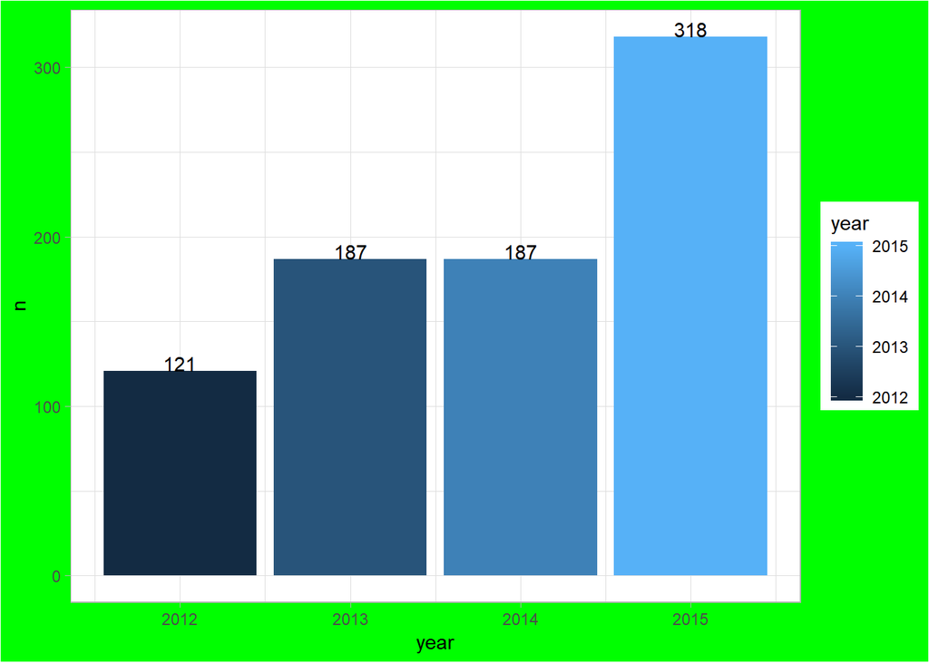

```r
    Q1 <-  SE %>% count(year)

      #ggplot(data = SE) +
      #  geom_bar(mapping = aes(year, fill = year), position = "dodge") +
      #  geom_text(aes(label = count ), position = "dodge") +
      #  theme_light() +
      #  theme(plot.background = element_rect(fill = "green"))

       ggplot(data = Q1, aes(year, n, group = year)) +
        geom_col(aes(fill = year), position = "dodge") +
          geom_text(aes(label = n ,  n = n + 0.05), position = position_dodge(0.9),
            vjust =0) +
        theme_light() +
        theme(plot.background = element_rect(fill = "green"))
```

> Interpretation

> > 2015 was the year where there was more progress regarding measures collected. 2013 and 2014 had almost the same number of measures collected.

## Question 7

> In which year and season the collection data process began?

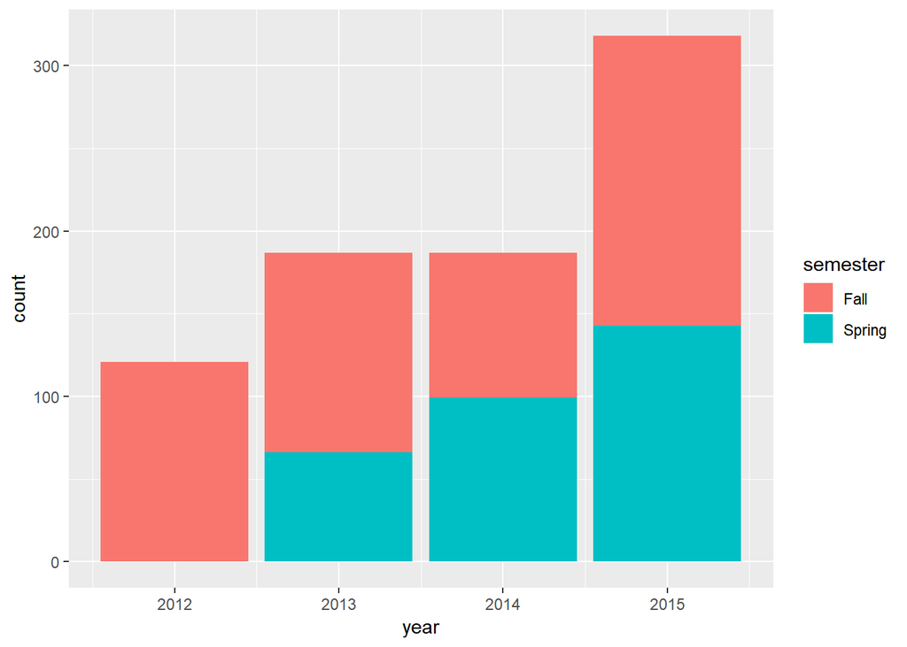

```r
      ggplot(SE, aes(year, fill = semester)) +
        geom_bar()
```

> Interpretation

> > Answering the question, 2012 FAll was the year and semester where the collection of measures began.

## Question 8.1

> How many observations the data shows per gender (male vs female) in total

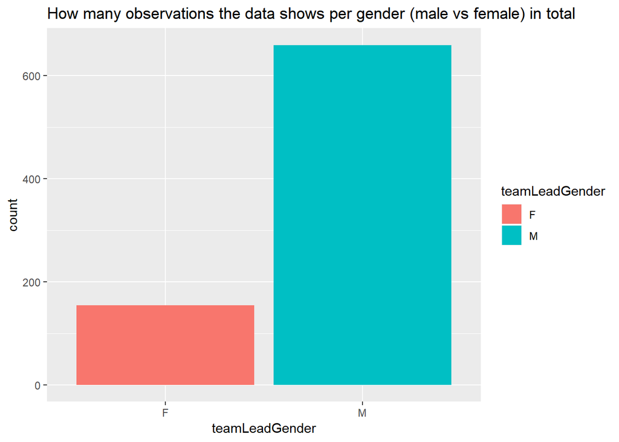

```r
    ggplot(data = SE) + geom_bar(mapping = aes(x = teamLeadGender, fill = teamLeadGender)) + ggtitle ("How many observations the data shows per gender (male vs female) in total")
```

> Interpretation

> > The number of observations where men are leaders quadruples the number of women.

## Question 8.2

> And how many observations per gender (male vs female) is divided by year?

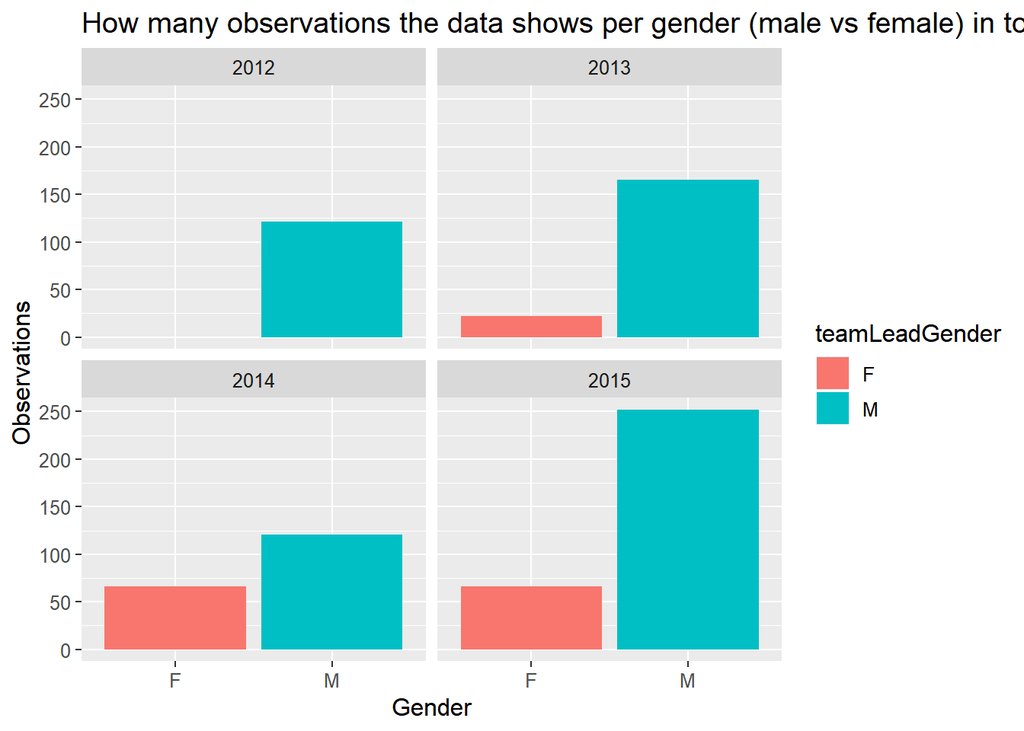

```r
 ggplot(data = SE) + geom_bar(mapping = aes(x = teamLeadGender, fill = teamLeadGender)) + theme (text = element_text(size=12)) + ggtitle ("How many observations the data shows per gender (male vs female) in total") + labs(x = "Gender",y = "Observations") +
      facet_wrap(~ year)
```

> Interpretation

> > In 2012 there were no women leaders In general, the number of men with respect to women is clearly higher in each year.

## Question 9

> How many students are grouped by each team? And how many students are grouped by each team per semester and per year? (This question should show 3 graphs)

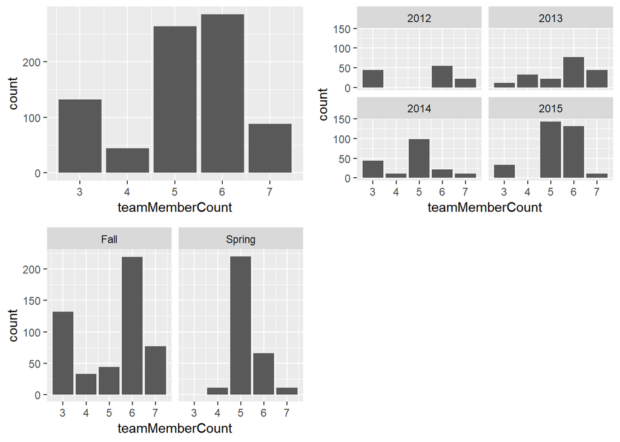

```r
Q9 <- SE %>% select(year, semester, teamNumber, teamMemberCount)

Q9.1 <- ggplot(Q9, aes(x= teamMemberCount)) +
        geom_bar()

Q9.2 <- ggplot(Q9, aes(x= teamMemberCount)) +
        geom_bar() +
      facet_wrap(~ year)

Q9.3 <- ggplot(Q9, aes(x= teamMemberCount)) +
        geom_bar() +
      facet_wrap(~ semester)

grid.arrange(Q9.1, Q9.2, Q9.3, nrow = 2)
```

> Interpretation

> > In general, most of the teams oscillate between 5 or 6 members.

## Question 10

> What is the relationship between the number of commits (commitCount) and the total hours of coding deliverables (codingDeliveablesHoursTotal)? Can we infer a relationship? Could we define this relationship as positive or negative?

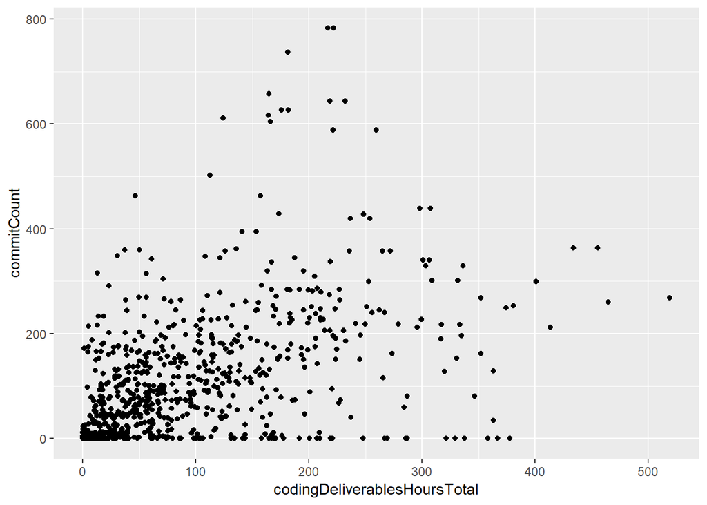

```r
QUESTION10 <- SE %>%
              select(commitCount, codingDeliverablesHoursTotal)

ggplot(QUESTION10, aes(x= codingDeliverablesHoursTotal, y=commitCount)) +
              geom_point()
```

> Interpretation

> > The graph is very concentrated between 0-100 codingDeliverableHoursTotal and 0-200 commitCount. The other data are more openly distributed among the other ranges.